# Home assignment 02: Data analysis Task 1

This is the second Almaz Murzabekov’s home assignment of Data analysis Task 1

### 1 Assignment on Confidence Intervals and Hypothesis Testing

```
1. Get a univariate dataset from sources 1 or 2 and briefly describe it. Using these data,
```

For this task I picked up stock prices of largest bank in Eustern Europe: Sberbank (SBER) from Moscow Exchange (MOEX). This datasets contains 9 columns and 192 rows (observations), each row in dataset describes the stock data (i.e. ticker, prices, volume, date, etc) for one day from 2019 January 3th till 2019 October 04.

```r
sber_stock_price = read.csv("data/t1/SBER.csv", header = TRUE, stringsAsFactors = FALSE)

summary(sber_stock_price)
```

```
    TICKER              PER                 DATE               TIME        OPEN            HIGH            LOW            CLOSE
 Length:192         Length:192         Min.   :20190103   Min.   :0   Min.   :186.4   Min.   :191.0   Min.   :186.0   Min.   :187.0
 Class :character   Class :character   1st Qu.:20190314   1st Qu.:0   1st Qu.:214.1   1st Qu.:215.9   1st Qu.:211.9   1st Qu.:214.0
 Mode  :character   Mode  :character   Median :20190522   Median :0   Median :226.6   Median :228.8   Median :224.5   Median :227.0
                                       Mean   :20190533   Mean   :0   Mean   :223.7   Mean   :225.8   Mean   :221.6   Mean   :223.8
                                       3rd Qu.:20190730   3rd Qu.:0   3rd Qu.:234.6   3rd Qu.:236.2   3rd Qu.:232.3   3rd Qu.:234.7
                                       Max.   :20191004   Max.   :0   Max.   :249.6   Max.   :250.7   Max.   :246.1   Max.   :249.0
      VOL
 Min.   : 12238240
 1st Qu.: 37782945
 Median : 47978555
 Mean   : 51621775
 3rd Qu.: 61565965
 Max.   :154867810
```

#### (a) Obtain a 97% confidence interval for the population mean.

Let’s obtain a 97% confidence interval for the price changes for each day of Sberbank’s stock prices. I suppouse that the price changes have random values for each day. So, to calculate the price changes we just need to calculate the difference between OPEN_PRICE and CLOSE_PRICE

```r
sber_close_prices_full = sber_stock_price$CLOSE - sber_stock_price$OPEN

sber_close_prices = sample(sber_close_prices_full, 100)

t.test(sber_close_prices, conf.level = 0.97)
```

```
    One Sample t-test

data:  sber_close_prices
t = -0.10329, df = 99, p-value = 0.9179
alternative hypothesis: true mean is not equal to 0
97 percent confidence interval:
 -0.5891881  0.5363881
sample estimates:
mean of x
  -0.0264
```

```r
median(sber_close_prices)
```

```
[1] -0.275
```

```r
t.test(sber_close_prices, mu = 0.53, alt = "two.sided")
```

```
    One Sample t-test

data:  sber_close_prices
t = -2.1768, df = 99, p-value = 0.03187
alternative hypothesis: true mean is not equal to 0.53
95 percent confidence interval:
 -0.5335688  0.4807688
sample estimates:
mean of x
  -0.0264
```

##### (c) Obtain a 95% confidence interval for the population standard deviation.

```r
n = length(sber_close_prices)
a = 0.05
variance = var(sber_close_prices)

lstar = qchisq(a / 2, df = n - 1)
rstar = qchisq(1 - a / 2, df = n - 1)

coeff = (n - 1) * c(1 / rstar, 1 / lstar)
coeff_sqrt = sqrt((n - 1) * c(1 / rstar, 1 / lstar))

coeff_sqrt
```

```
[1] 0.8780068 1.1616753
```

##### (d) Find some dataset with a categorical variable. For that variable, compute the proportion of some level. Obtain a 99% confidence interval for that proportion.

Unfornutelly, sberbank_stock_prices have’not any categorical field. So, I decided create categorical field by some simple logic: NEW_FIELD = if (day_price_delta > 0) UP else DOWN

Now, lets calculate this field:

```r
sber_up_down_variables = ifelse(sber_close_prices_full > 0, TRUE, FALSE)
length(sber_up_down_variables)
```

```
[1] 192
```

```r
length(sber_up_down_variables[sber_up_down_variables == TRUE])
```

```
[1] 97
```

```r
length(sber_up_down_variables[sber_up_down_variables == FALSE])
```

```
[1] 95
```

```r
sber_up_down_prices_sample = sample(sber_up_down_variables,  100)
mean(sber_up_down_prices_sample)
```

```
[1] 0.51
```

```r
prop.test(48, 100, conf.level=0.99)
```

```
    1-sample proportions test with continuity correction

data:  48 out of 100, null probability 0.5
X-squared = 0.09, df = 1, p-value = 0.7642
alternative hypothesis: true p is not equal to 0.5
99 percent confidence interval:
 0.3519814 0.6106010
sample estimates:
   p
0.48
```

##### (e) Perform a hypothesis test on whether the population proportion is equal to 1/2. Clearly state the null and alternative hypotheses, provide the p-value.

In this part I wanna check that DOWN AND UP day groups in this dataset presents with proporition 1:2 (that means there are twice more days with UP prices: (paradise for traders and investors :), of couse it is not true)

```r
prop.test(x = 48, n = 100, p = .33, alt = "greater")
```

```
    1-sample proportions test with continuity correction

data:  48 out of 100, null probability 0.33
X-squared = 9.5093, df = 1, p-value = 0.001022
alternative hypothesis: true p is greater than 0.33
95 percent confidence interval:
 0.3946052 1.0000000
sample estimates:
   p
0.48
```

As I expected, according with EMH, proption for DOWN days are greather 33%, so we might to discover the H1

##### (f) Come up with some data for calculating the confidence intervals between proportions of two populations (in fact, you need just four numbers). Obtain a 99% confidence interval for the difference between proportions.

For this part I will take the monthly performances (in percent) by IMOEX and SBER for several months (Note: this performances are not real, just random numbers)

```r
imoex_perf = c(8.10, 3.54, 6.17,  0.23, -4.12, 2.98)
sber_perf  = c(12.7, 4.80, 3.42, -1.56, -6.89, 3.23)

t.test(imoex_perf, sber_perf, var.equal = TRUE, conf.level = 0.99)
```

```
    Two Sample t-test

data:  imoex_perf and sber_perf
t = 0.062237, df = 10, p-value = 0.9516
alternative hypothesis: true difference in means is not equal to 0
99 percent confidence interval:
 -9.984497 10.384497
sample estimates:
mean of x mean of y
 2.816667  2.616667
```

Hm… The differences between two financial instrument are between -9.9844 and +10.3844

##### (g) Perform an appropriate hypothesis test for the difference between proportions (perhaps, using imaginary data). Draw a conclusion.

We know the correlation between sberbank stocks (SBER) and Index of Moscow Exchange (IMOEX) is ~0.67. So, using this observation we can propose hypothesis that 67% of each day performance of SBER and 60% of IMOEX are equal (I know this is a stupid hypothesis, btw why not?!)

```r
prop.test(c(192 * 0.67, 192 * 0.60), c(192, 192), alt = "less")
```

```
    2-sample test for equality of proportions with continuity correction

data:  c(192 * 0.67, 192 * 0.6) out of c(192, 192)
X-squared = 1.7388, df = 1, p-value = 0.9064
alternative hypothesis: less
95 percent confidence interval:
 -1.0000000  0.1558156
sample estimates:
prop 1 prop 2
  0.67   0.60
```

We fail to reject H0 since p-value = 0.9064 > 0.05 (setted by default) and conclude that with 95% confidence there is no significant difference between the proportions

```
2. Pick the time series of log returns (make sure you understand what this means) on three securities or commodities from data sources 1. Use getSymbols command to download the data and:
```

The same dataset (SBER) was choosen as well for this part of the work assignment, and also I picked up the prices of stock GAZP (Gazprom) and prices of Index of Moscow Exchange (IMOEX)

##### (a) Perform the Jarque-Bera for normality. State clearly the null and alternative hypothesis.

There are the same logic for preporation dataset (Just technical moment)

```r
sber_stock_prices_full = read.csv("data/t1/SBER.csv", header = TRUE, stringsAsFactors = FALSE)
gazp_stock_prices_full = read.csv("data/t1/GAZP.csv", header = TRUE, stringsAsFactors = FALSE)
imoex_prices_full = read.csv("data/t1/IMOEX.csv", header = TRUE, stringsAsFactors = FALSE)

sber_close_prices_full = sber_stock_prices_full$CLOSE - sber_stock_prices_full$OPEN
gazp_close_prices_full = gazp_stock_prices_full$CLOSE - gazp_stock_prices_full$OPEN
imoex_close_prices_full = imoex_prices_full$CLOSE - imoex_prices_full$OPEN
```

```r
library(tseries)

jarque.bera.test(sber_close_prices_full)
```

```
    Jarque Bera Test

data:  sber_close_prices_full
X-squared = 0.085442, df = 2, p-value = 0.9582
```

```r
jarque.bera.test(gazp_close_prices_full)
```

```
    Jarque Bera Test

data:  gazp_close_prices_full
X-squared = 3095.7, df = 2, p-value < 2.2e-16
```

```r
jarque.bera.test(imoex_close_prices_full)
```

```
    Jarque Bera Test

data:  imoex_close_prices_full
X-squared = 11.652, df = 2, p-value = 0.00295
```

How to interpret this result? Especially Jarque Bera Test for GAZP prices?

I’m not totally sure, but as I understood there very small value of p-value of GAZP financial institution means we should reject the null hypothesis, also it means the ditributions of each day price deltas are not normal.

Note: The EMH declares the distribution of each day price changes of any fin instrument are normal (or log-normal) in efficient market. Is it correct to say: The Russian Stock market has an fin instrument like GAZP that not not efficient in terms of EMH?

##### (b) Check whether the (univariate) empirical distribution of log returns for each stock is normal by examining the QQ-plot. Use the command qqPlot() from car package instead of the built-in function. Discuss whether the observations are within the confidence interval.

```
[1] 104  79
```

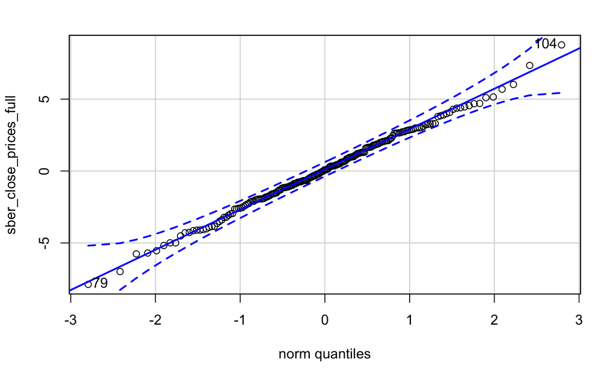

```r
library(car)

qqPlot(sber_close_prices_full)
```

```
[1]  90 104
```

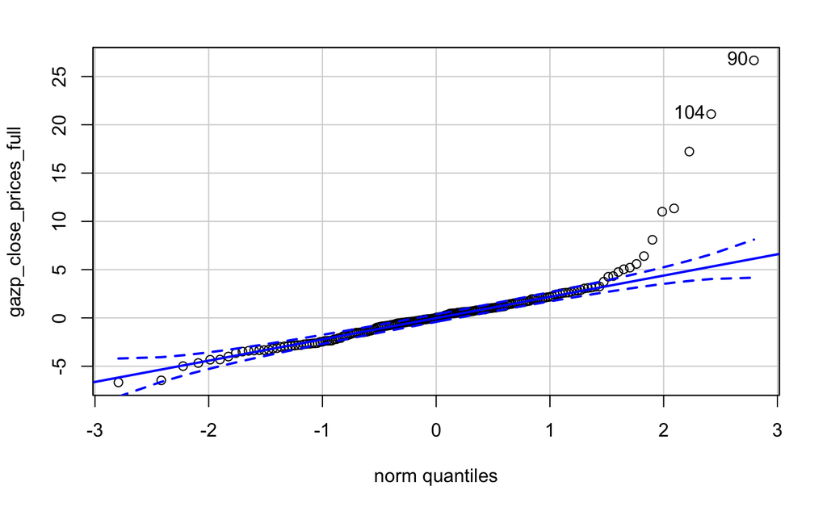

```r
qqPlot(gazp_close_prices_full)
```

```
[1] 104  29
```

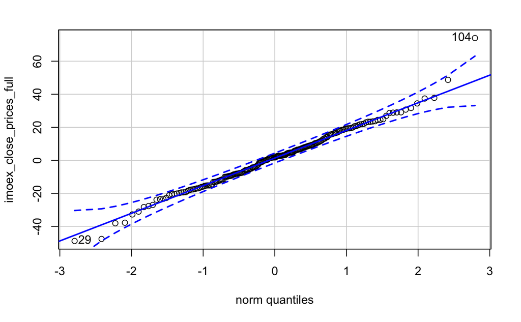

```r
qqPlot(imoex_close_prices_full)
```

For GAZP’s plot I have a strange graph, that means the distribution of day deltas is not seems like normal distribution. So, if we draw simple histrogram we should see the some skeweness left or right.

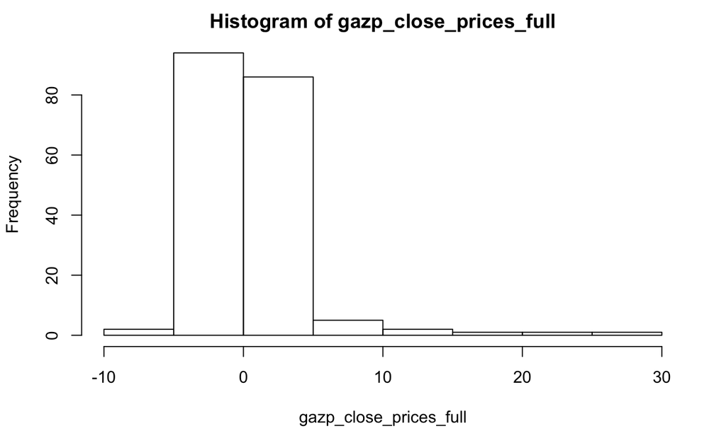

```r
hist(gazp_close_prices_full)
```

```
3. Use a built-in set from 2 to perform the χ2-test for homogeneity (uniform distribution).
```

Describe the data and discuss the result. See lecture slides and Section 9.1.2 of [1].

In this moment I have not free time to selecting any beautiful dataset, so sorry for that, and I just choose the volumes of trades for first 5 trade-days for the same instruments.

```r
sber_volumes = sber_stock_prices_full$VOL[0:5]
gazp_volumes = gazp_stock_prices_full$VOL[0:5]
imoex_volumes = imoex_prices_full$VOL[0:5]

trade_volumes <- rbind(sber_volumes, gazp_volumes, imoex_volumes)
colnames(trade_volumes) <- c("Mon", "Tue", "Wed", "Thur", "Fri")
trade_volumes
```

```
                      Mon         Tue         Wed        Thur         Fri
sber_volumes     40105780    32537090    38581950    70633230    56211650
gazp_volumes     14156530    14532100    16952510    19132150    19908540
imoex_volumes 23065788705 19959820960 26939659761 36438416186 34451721995
```

```r
chisq.test(trade_volumes)
```

```
    Pearson's Chi-squared test

data:  trade_volumes
X-squared = 3489831, df = 8, p-value < 2.2e-16
```

The p-value of x2-test is less than the signficiance level 10% or 5%, that means these groups are heterogeneous

```
4. Get a two-way contingency table from sources 3. Conduct a χ2-test for association (independence) between the variables. See lecture slides and Section 9.2 of [1]
```

Also, using the same dataset as in a previous part - the first 5 day trading voolumes of SBER, GAZP, IMOEX.

Let’s declare two hypotheses: (H1): The trading-volume and trading-day for fin instrument are independent variables. There is no association between volumes and trading day. (H2): The trading-volume and trading-day for fin instrument are dependent variables. There is an association between volumes and trading day.

To accept or reject the null hypothesis, I choose significant level of 5%.

Note: There are some researches (in smartlab, yahoo.finance, that shows the trading-volume have some correlation with day-of week)

```r
trade_volumes_chi_test <- chisq.test(trade_volumes, correct = TRUE)
trade_volumes_chi_test
```

```
    Pearson's Chi-squared test

data:  trade_volumes
X-squared = 3489831, df = 8, p-value < 2.2e-16
```

```r
trade_volumes_chi_test$expected
```

```
                      Mon         Tue         Wed        Thur         Fri
sber_volumes     38987501    33737756    45522182    61597724    58224538
gazp_volumes     13867926    12000582    16192324    21910424    20710575
imoex_volumes 23067195588 19961151812 26933479716 36444673419 34448907072
```

### REFERENCES

[1] econometrics-with-r.org: https://www.econometrics-with-r.org/3-4-confidence-intervals-for-the-population-mean.html [2] Understanding QQ-plots: https://data.library.virginia.edu/understanding-q-q-plots/ [3] Эффективное время для торговли в течении сессии https://smart-lab.ru/finansoviy-slovar/%D0%AD%D1%84%D1%84%D0%B5%D0%BA%D1%82%D0%B8%D0%B2%D0%BD%D0%BE%D0%B5%20%D0%B2%D1%80%D0%B5%D0%BC%D1%8F%20%D0%B4%D0%BB%D1%8F%20%D1%82%D0%BE%D1%80%D0%B3%D0%BE%D0%B2%D0%BB%D0%B8%20%D0%B2%20%D1%82%D0%B5%D1%87%D0%B5%D0%BD%D0%B8%D0%B8%20%D1%81%D0%B5%D1%81%D1%81%D0%B8%D0%B8